# Session 4

## Template Hui-Walter

The model code and data format for an arbitrary number of populations (and tests) can be determined automatically using the template_huiwalter function from the runjags package:

```r
template_huiwalter(
  covid_data %>% select(Population, NoseAG, ThroatAG, ThroatPCR),
  outfile = 'covidmodel.txt')
```

This generates self-contained model/data/initial values etc

```
model{

    ## Observation layer:

    # Complete observations (N=20000):
    for(p in 1:Populations){
        Tally_RRR[1:8,p] ~ dmulti(prob_RRR[1:8,p], N_RRR[p])

        prob_RRR[1:8,p] <- se_prob[1:8,p] + sp_prob[1:8,p]
    }


    ## Observation probabilities:

    for(p in 1:Populations){

        # Probability of observing NoseAG- ThroatAG- ThroatPCR- from a true positive::
        se_prob[1,p] <- prev[p] * ((1-se[1])*(1-se[2])*(1-se[3]) +covse12 +covse13 +covse23)
        # Probability of observing NoseAG- ThroatAG- ThroatPCR- from a true negative::
        sp_prob[1,p] <- (1-prev[p]) * (sp[1]*sp[2]*sp[3] +covsp12 +covsp13 +covsp23)

        # Probability of observing NoseAG+ ThroatAG- ThroatPCR- from a true positive::
        se_prob[2,p] <- prev[p] * (se[1]*(1-se[2])*(1-se[3]) -covse12 -covse13 +covse23)
        # Probability of observing NoseAG+ ThroatAG- ThroatPCR- from a true negative::
        sp_prob[2,p] <- (1-prev[p]) * ((1-sp[1])*sp[2]*sp[3] -covsp12 -covsp13 +covsp23)

        # Probability of observing NoseAG- ThroatAG+ ThroatPCR- from a true positive::
        se_prob[3,p] <- prev[p] * ((1-se[1])*se[2]*(1-se[3]) -covse12 +covse13 -covse23)
        # Probability of observing NoseAG- ThroatAG+ ThroatPCR- from a true negative::
        sp_prob[3,p] <- (1-prev[p]) * (sp[1]*(1-sp[2])*sp[3] -covsp12 +covsp13 -covsp23)

        # Probability of observing NoseAG+ ThroatAG+ ThroatPCR- from a true positive::
        se_prob[4,p] <- prev[p] * (se[1]*se[2]*(1-se[3]) +covse12 -covse13 -covse23)
        # Probability of observing NoseAG+ ThroatAG+ ThroatPCR- from a true negative::
        sp_prob[4,p] <- (1-prev[p]) * ((1-sp[1])*(1-sp[2])*sp[3] +covsp12 -covsp13 -covsp23)

        # Probability of observing NoseAG- ThroatAG- ThroatPCR+ from a true positive::
        se_prob[5,p] <- prev[p] * ((1-se[1])*(1-se[2])*se[3] +covse12 -covse13 -covse23)
        # Probability of observing NoseAG- ThroatAG- ThroatPCR+ from a true negative::
        sp_prob[5,p] <- (1-prev[p]) * (sp[1]*sp[2]*(1-sp[3]) +covsp12 -covsp13 -covsp23)

        # Probability of observing NoseAG+ ThroatAG- ThroatPCR+ from a true positive::
        se_prob[6,p] <- prev[p] * (se[1]*(1-se[2])*se[3] -covse12 +covse13 -covse23)
        # Probability of observing NoseAG+ ThroatAG- ThroatPCR+ from a true negative::
        sp_prob[6,p] <- (1-prev[p]) * ((1-sp[1])*sp[2]*(1-sp[3]) -covsp12 +covsp13 -covsp23)

        # Probability of observing NoseAG- ThroatAG+ ThroatPCR+ from a true positive::
        se_prob[7,p] <- prev[p] * ((1-se[1])*se[2]*se[3] -covse12 -covse13 +covse23)
        # Probability of observing NoseAG- ThroatAG+ ThroatPCR+ from a true negative::
        sp_prob[7,p] <- (1-prev[p]) * (sp[1]*(1-sp[2])*(1-sp[3]) -covsp12 -covsp13 +covsp23)

        # Probability of observing NoseAG+ ThroatAG+ ThroatPCR+ from a true positive::
        se_prob[8,p] <- prev[p] * (se[1]*se[2]*se[3] +covse12 +covse13 +covse23)
        # Probability of observing NoseAG+ ThroatAG+ ThroatPCR+ from a true negative::
        sp_prob[8,p] <- (1-prev[p]) * ((1-sp[1])*(1-sp[2])*(1-sp[3]) +covsp12 +covsp13 +covsp23)

    }


    ## Priors:

    # Prevalence in population 1:
    prev[1] ~ dbeta(1,1)

    # Prevalence in population 2:
    prev[2] ~ dbeta(1,1)


    # Sensitivity of NoseAG test:
    se[1] ~ dbeta(1,1)T(1-sp[1], )
    # Specificity of NoseAG test:
    sp[1] ~ dbeta(1,1)

    # Sensitivity of ThroatAG test:
    se[2] ~ dbeta(1,1)T(1-sp[2], )
    # Specificity of ThroatAG test:
    sp[2] ~ dbeta(1,1)

    # Sensitivity of ThroatPCR test:
    se[3] ~ dbeta(1,1)T(1-sp[3], )
    # Specificity of ThroatPCR test:
    sp[3] ~ dbeta(1,1)


    # Covariance in sensitivity between NoseAG and ThroatAG tests:
    # covse12 ~ dunif( (se[1]-1)*(1-se[2]) , min(se[1],se[2]) - se[1]*se[2] )  ## if the sensitivity of these tests may be correlated
    covse12 <- 0  ## if the sensitivity of these tests can be assumed to be independent
    # Calculated relative to the min/max for ease of interpretation:
    corse12 <- ifelse(covse12 < 0, -covse12 / ((se[1]-1)*(1-se[2])), covse12 / (min(se[1],se[2]) - se[1]*se[2]))

    # Covariance in specificity between NoseAG and ThroatAG tests:
    # covsp12 ~ dunif( (sp[1]-1)*(1-sp[2]) , min(sp[1],sp[2]) - sp[1]*sp[2] )  ## if the specificity of these tests may be correlated
    covsp12 <- 0  ## if the specificity of these tests can be assumed to be independent
    # Calculated relative to the min/max for ease of interpretation:
    corsp12 <- ifelse(covsp12 < 0, -covsp12 / ((sp[1]-1)*(1-sp[2])), covsp12 / (min(sp[1],sp[2]) - sp[1]*sp[2]))

    # Covariance in sensitivity between NoseAG and ThroatPCR tests:
    # covse13 ~ dunif( (se[1]-1)*(1-se[3]) , min(se[1],se[3]) - se[1]*se[3] )  ## if the sensitivity of these tests may be correlated
    covse13 <- 0  ## if the sensitivity of these tests can be assumed to be independent
    # Calculated relative to the min/max for ease of interpretation:
    corse13 <- ifelse(covse13 < 0, -covse13 / ((se[1]-1)*(1-se[3])), covse13 / (min(se[1],se[3]) - se[1]*se[3]))

    # Covariance in specificity between NoseAG and ThroatPCR tests:
    # covsp13 ~ dunif( (sp[1]-1)*(1-sp[3]) , min(sp[1],sp[3]) - sp[1]*sp[3] )  ## if the specificity of these tests may be correlated
    covsp13 <- 0  ## if the specificity of these tests can be assumed to be independent
    # Calculated relative to the min/max for ease of interpretation:
    corsp13 <- ifelse(covsp13 < 0, -covsp13 / ((sp[1]-1)*(1-sp[3])), covsp13 / (min(sp[1],sp[3]) - sp[1]*sp[3]))

    # Covariance in sensitivity between ThroatAG and ThroatPCR tests:
    # covse23 ~ dunif( (se[2]-1)*(1-se[3]) , min(se[2],se[3]) - se[2]*se[3] )  ## if the sensitivity of these tests may be correlated
    covse23 <- 0  ## if the sensitivity of these tests can be assumed to be independent
    # Calculated relative to the min/max for ease of interpretation:
    corse23 <- ifelse(covse23 < 0, -covse23 / ((se[2]-1)*(1-se[3])), covse23 / (min(se[2],se[3]) - se[2]*se[3]))

    # Covariance in specificity between ThroatAG and ThroatPCR tests:
    # covsp23 ~ dunif( (sp[2]-1)*(1-sp[3]) , min(sp[2],sp[3]) - sp[2]*sp[3] )  ## if the specificity of these tests may be correlated
    covsp23 <- 0  ## if the specificity of these tests can be assumed to be independent
    # Calculated relative to the min/max for ease of interpretation:
    corsp23 <- ifelse(covsp23 < 0, -covsp23 / ((sp[2]-1)*(1-sp[3])), covsp23 / (min(sp[2],sp[3]) - sp[2]*sp[3]))

}

#monitor# se, sp, prev, covse12, corse12, covsp12, corsp12, covse13, corse13, covsp13, corsp13, covse23, corse23, covsp23, corsp23

## Inits:
inits{
"se" <- c(0.5, 0.99, 0.5)
"sp" <- c(0.99, 0.75, 0.99)
"prev" <- c(0.05, 0.95)
# "covse12" <- 0
# "covse13" <- 0
# "covse23" <- 0
# "covsp12" <- 0
# "covsp13" <- 0
# "covsp23" <- 0
}
inits{
"se" <- c(0.99, 0.5, 0.99)
"sp" <- c(0.75, 0.99, 0.75)
"prev" <- c(0.95, 0.05)
# "covse12" <- 0
# "covse13" <- 0
# "covse23" <- 0
# "covsp12" <- 0
# "covsp13" <- 0
# "covsp23" <- 0
}
```

```
## Data:
data{
"Populations" <- 2
"N_RRR" <- c(9934, 10066)
"Tally_RRR" <- structure(c(8795, 466, 496, 18, 89, 17, 20, 33, 8579, 507, 432, 25, 132, 74, 124, 193), .Dim = c(8, 2))
}
```

And can be run directly from R:

```r
results <- run.jags('covidmodel.txt')
## Loading required namespace: rjags
results
```

|  | Lower95 | Median | Upper95 | SSeff | psrf |
| --- | --- | --- | --- | --- | --- |
| se[1] | 0.568 | 0.618 | 0.667 | 7257 | 1 |
| se[2] | 0.676 | 0.728 | 0.776 | 6759 | 1 |
| se[3] | 0.948 | 0.984 | 1.000 | 5886 | 1 |
| sp[1] | 0.944 | 0.948 | 0.951 | 11695 | 1 |
| sp[2] | 0.947 | 0.950 | 0.953 | 10810 | 1 |
| sp[3] | 0.989 | 0.990 | 0.992 | 6634 | 1 |
| prev[1] | 0.005 | 0.007 | 0.009 | 9991 | 1 |
| prev[2] | 0.039 | 0.043 | 0.048 | 7157 | 1 |
| covse12 | 0.000 | 0.000 | 0.000 | NA | NA |
| covsp12 | 0.000 | 0.000 | 0.000 | NA | NA |
| covse13 | 0.000 | 0.000 | 0.000 | NA | NA |
| covsp13 | 0.000 | 0.000 | 0.000 | NA | NA |
| covse23 | 0.000 | 0.000 | 0.000 | NA | NA |
| covsp23 | 0.000 | 0.000 | 0.000 | NA | NA |

## Template Hui-Walter

- Modifying priors must still be done directly in the model file
  - Same for adding .RNG.seed and the deviance monitor
- The model needs to be re-generated if the data changes
  - But remember that your modified priors will be reset
- There must be a single column for the population (as a factor), and all of the other columns (either factor, logical or numeric) are interpreted as being test results
- Covariance terms are also calculated as proportion of possible correlation e.g.:

```
    # Covariance in sensitivity between NoseAG and ThroatAG tests:
    # covse12 ~ dunif( (se[1]-1)*(1-se[2]) , min(se[1],se[2]) - se[1]*se[2] )  ## if the sensitivity of these tests may be correlated
    covse12 <- 0  ## if the sensitivity of these tests can be assumed to be independent
    # Calculated relative to the min/max for ease of interpretation:
    corse12 <- ifelse(covse12 < 0, -covse12 / ((se[1]-1)*(1-se[2])), covse12 / (min(se[1],se[2]) - se[1]*se[2]))
```

- But covariance terms are all deactivated by default!

## Activating covariance terms

Find the lines for the covariances that we want to activate (i.e. the two Throat tests):

```
# Covariance in sensitivity between ThroatAG and ThroatPCR tests:
# covse23 ~ dunif( (se[2]-1)*(1-se[3]) , min(se[2],se[3]) - se[2]*se[3] )  ## if the sensitivity of these tests may be correlated
covse23 <- 0  ## if the sensitivity of these tests can be assumed to be independent

# Covariance in specificity between ThroatAG and ThroatPCR tests:
# covsp23 ~ dunif( (sp[2]-1)*(1-sp[3]) , min(sp[2],sp[3]) - sp[2]*sp[3] )  ## if the specificity of these tests may be correlated
covsp23 <- 0  ## if the specificity of these tests can be assumed to be independent
```

And edit so it looks like:

```
# Covariance in sensitivity between ThroatAG and ThroatPCR tests:
covse23 ~ dunif( (se[2]-1)*(1-se[3]) , min(se[2],se[3]) - se[2]*se[3] )  ## if the sensitivity of these tests may be correlated
 # covse23 <- 0  ## if the sensitivity of these tests can be assumed to be independent

# Covariance in specificity between ThroatAG and ThroatPCR tests:
covsp23 ~ dunif( (sp[2]-1)*(1-sp[3]) , min(sp[2],sp[3]) - sp[2]*sp[3] )  ## if the specificity of these tests may be correlated
 # covsp23 <- 0  ## if the specificity of these tests can be assumed to be independent
```

[i.e. swap the comments around]

```
# "covse12" <- 0
# "covse13" <- 0
# "covse23" <- 0
# "covsp12" <- 0
# "covsp13" <- 0
# "covsp23" <- 0
```

So that they look like:

```
# "covse12" <- 0
# "covse13" <- 0
"covse23" <- 0
# "covsp12" <- 0
# "covsp13" <- 0
"covsp23" <- 0
```

```r
results <- run.jags('covidmodel.txt', sample=50000)
results
##
## JAGS model summary statistics from 100000 samples (chains = 2; adapt+burnin = 5000):
##
##             Lower95    Median    Upper95       Mean         SD       Mode
## se[1]       0.57241   0.62921    0.69086    0.62971   0.030146    0.62947
## se[2]       0.51891   0.64434    0.75288    0.63971   0.062513    0.65217
## se[3]       0.75077   0.90179          1    0.89056   0.075659    0.95248
## sp[1]       0.94508   0.94912    0.95358    0.94923  0.0021741    0.94905
## sp[2]       0.94551   0.94893     0.9522    0.94891  0.0017193    0.94903
## sp[3]       0.98761   0.98984    0.99193    0.98979  0.0011129    0.98997
## prev[1]   0.0052447 0.0074595   0.010114  0.0075498   0.001253  0.0073432
## prev[2]    0.039476  0.046588   0.056272   0.047179  0.0044625   0.045573
## covse12           0         0          0          0          0          0
## corse12           0         0          0          0          0          0
## covsp12           0         0          0          0          0          0
## corsp12           0         0          0          0          0          0
## covse13           0         0          0          0          0          0
## corse13           0         0          0          0          0          0
## covsp13           0         0          0          0          0          0
## corsp13           0         0          0          0          0          0
## covse23  -0.0032372  0.038032    0.08304   0.038282    0.02562   0.018934
## corse23    0.040207   0.58456    0.99996    0.54026    0.28735    0.59761
## covsp23 -0.00040183 0.0001559 0.00066469 0.00015552 0.00027659 0.00018261
## corsp23     -0.6191  0.016175    0.10048  -0.080101    0.21875    0.01967
##
##               MCerr MC%ofSD SSeff    AC.10    psrf
## se[1]    0.00025078     0.8 14450 0.041477 0.99997
## se[2]     0.0016396     2.6  1454  0.66495  1.0002
## se[3]     0.0021044     2.8  1293  0.76134  1.0002
## sp[1]   0.000044199       2  2420  0.35962  1.0001
## sp[2]   0.000016481       1 10883 0.050804       1
## sp[3]   0.000012213     1.1  8303 0.097744       1
## prev[1] 0.000017048     1.4  5402  0.17719  1.0001
## prev[2]  0.00010367     2.3  1853  0.51789  1.0001
## covse12          --      --    --       --      --
## corse12          --      --    --       --      --
## covsp12          --      --    --       --      --
## corsp12          --      --    --       --      --
## covse13          --      --    --       --      --
## corse13          --      --    --       --      --
## covsp13          --      --    --       --      --
## corsp13          --      --    --       --      --
## covse23  0.00070853     2.8  1308  0.73019  1.0001
## corse23   0.0035262     1.2  6640  0.13883  1.0004
## covsp23  2.2094e-06     0.8 15672 0.011558       1
## corsp23   0.0017132     0.8 16303 0.011887  1.0001
##
## Total time taken: 4.3 seconds
```

## Practical considerations

- Correlation terms add complexity to the model in terms of:
  - Opportunity to make a coding mistake
  - Reduced identifiability
- The template_huiwalter function helps us with coding mistakes
- Only careful consideration of covariance terms can help us with identifiability

# How to interpret the latent class

## A hierarchy of latent states

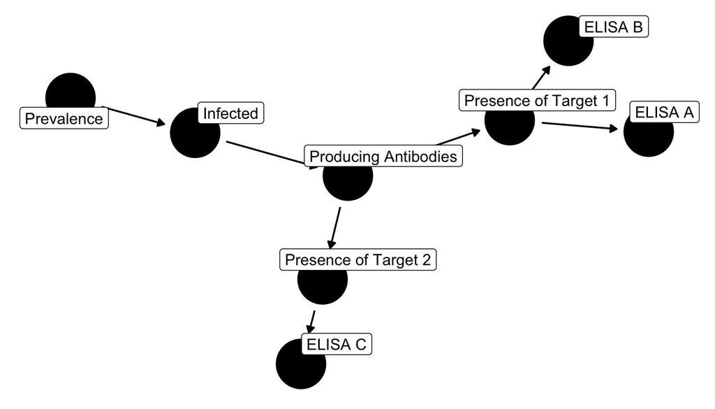

## What is sensitivity and specificity?

- The probability of test status conditional on true disease status?
- The probability of test status conditional on the latent state?

So is the latent state the same as the true disease state?

Important quote:

“Latent class models involve pulling **something** out of a hat, and deciding to call it a rabbit”

- Nils Toft

## When should we correct for correlation?

- For each of the following DAG:
  - Consider what is the latent class
  - Consider which correlation terms we should include and why

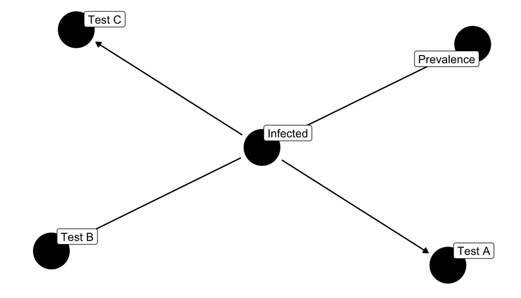

- No correlation to model!

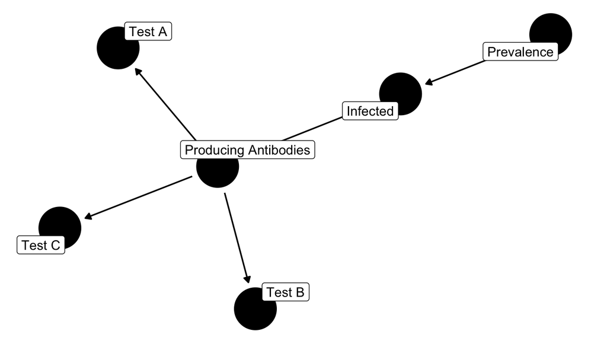

- No correlation to model … but “infected” is not the latent class

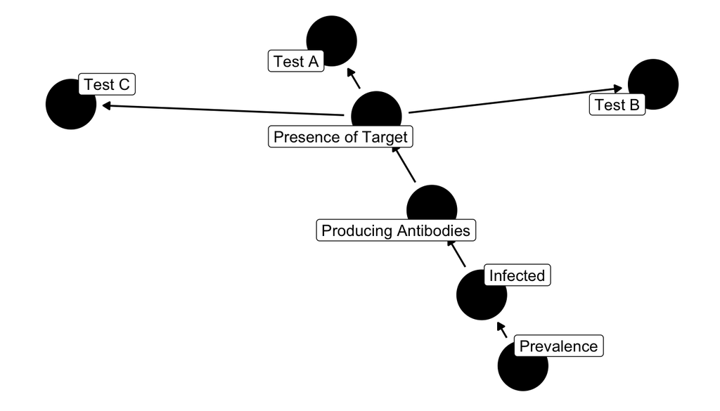

- Same as above!

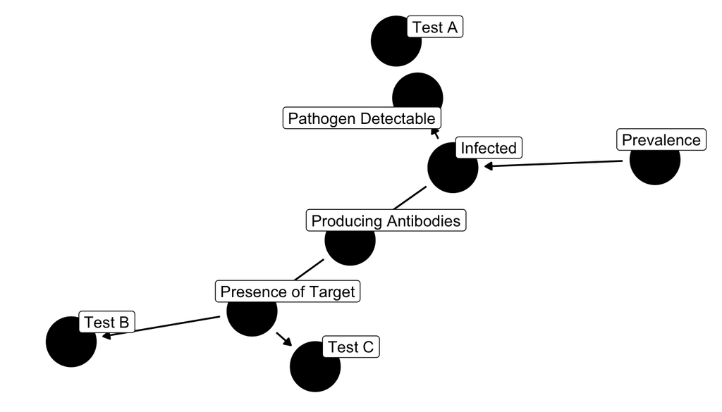

- Tests B and C are correlated

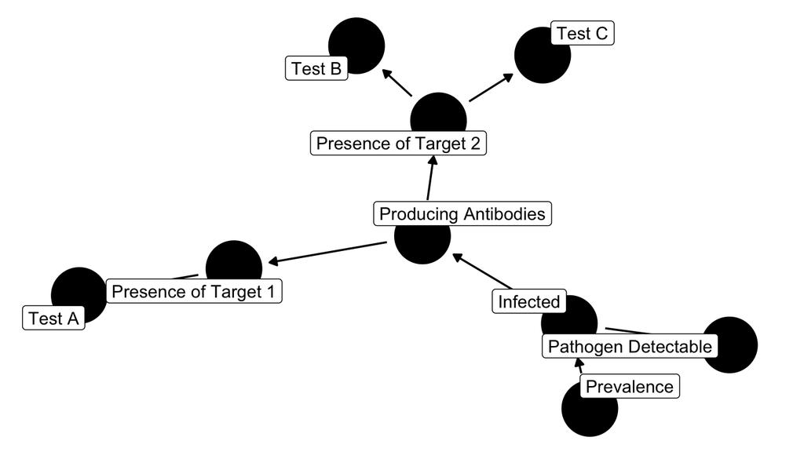

- All tests are correlated with respect to infected BUT infected is not the latent class
- Tests B and C are correlated with respect to antibodies - but maybe not substantially?

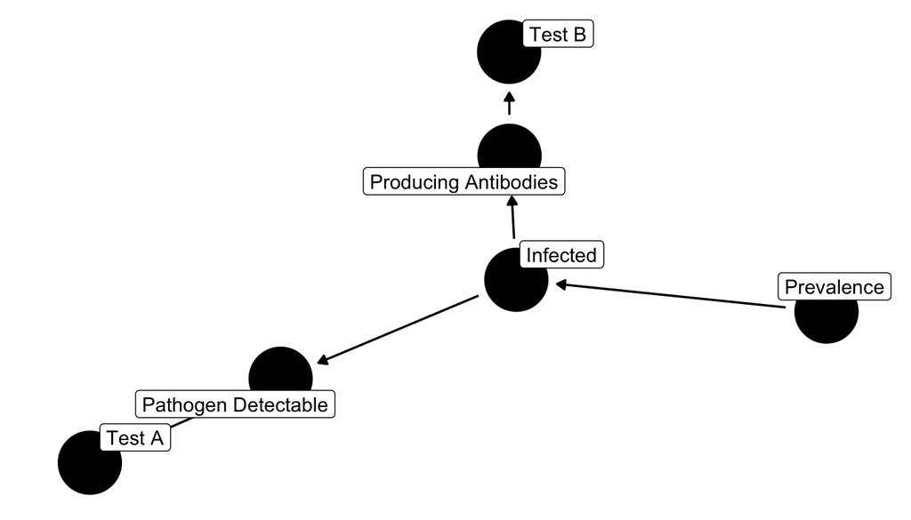

- No correlation to model

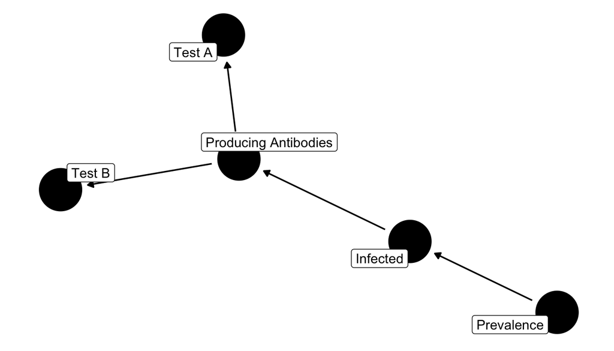

- No correlation to model - but “infected” is not the latent class

## Publication of your results

STARD-BLCM: A helpful structure to ensure that papers contain all necessary information

- You should follow this and refer to it in your articles!

If you use the software, please cite JAGS:

- Plummer, M. (2003). JAGS : A Program for Analysis of Bayesian Graphical Models Using Gibbs Sampling JAGS : Just Another Gibbs Sampler. Proceedings of the 3rd International Workshop on Distributed Statistical Computing (DSC 2003), March 20–22,Vienna, Austria. ISSN 1609-395X. https://doi.org/10.1.1.13.3406

And R:

```r
citation()
##
## To cite R in publications use:
##
##   R Core Team (2022). R: A language and environment for statistical
##   computing. R Foundation for Statistical Computing, Vienna, Austria.
##   URL https://www.R-project.org/.
##
## A BibTeX entry for LaTeX users is
##
##   @Manual{,
##     title = {R: A Language and Environment for Statistical Computing},
##     author = {{R Core Team}},
##     organization = {R Foundation for Statistical Computing},
##     address = {Vienna, Austria},
##     year = {2022},
##     url = {https://www.R-project.org/},
##   }
##
## We have invested a lot of time and effort in creating R, please cite it
## when using it for data analysis. See also 'citation("pkgname")' for
## citing R packages.
```

And runjags:

```r
citation("runjags")
##
## To cite runjags in publications use:
##
##   Matthew J. Denwood (2016). runjags: An R Package Providing Interface
##   Utilities, Model Templates, Parallel Computing Methods and Additional
##   Distributions for MCMC Models in JAGS. Journal of Statistical
##   Software, 71(9), 1-25. doi:10.18637/jss.v071.i09
##
## A BibTeX entry for LaTeX users is
##
##   @Article{,
##     title = {{runjags}: An {R} Package Providing Interface Utilities, Model Templates, Parallel Computing Methods and Additional Distributions for {MCMC} Models in {JAGS}},
##     author = {Matthew J. Denwood},
##     journal = {Journal of Statistical Software},
##     year = {2016},
##     volume = {71},
##     number = {9},
##     pages = {1--25},
##     doi = {10.18637/jss.v071.i09},
##   }
```

# Practical session 4

## Points to consider

1. How does including a third test impact the inference for the first two tests?
2. What happens if we include correlation between tests?

## Exercise 1

Use the template_huiwalter function to look at the simple 2-test 5-population example from session 3. Use this data simulation code:

```r
# Set a random seed so that the data are reproducible:
set.seed(2022-09-13)

sensitivity <- c(0.9, 0.6)
specificity <- c(0.95, 0.9)
N <- 1000

# Change the number of populations here:
Populations <- 5
# Change the variation in prevalence here:
(prevalence <- runif(Populations, min=0.1, max=0.9))
## [1] 0.2572767 0.6731408 0.3896685 0.4128620 0.7506458
data <- tibble(Population = sample(seq_len(Populations), N, replace=TRUE)) %>%
  mutate(Status = rbinom(N, 1, prevalence[Population])) %>%
  mutate(Test1 = rbinom(N, 1, sensitivity[1]*Status + (1-specificity[1])*(1-Status))) %>%
  mutate(Test2 = rbinom(N, 1, sensitivity[2]*Status + (1-specificity[2])*(1-Status))) %>%
  select(-Status)

(twoXtwoXpop <- with(data, table(Test1, Test2, Population)))
## , , Population = 1
##
##      Test2
## Test1   0   1
##     0 129  14
##     1  30  29
##
## , , Population = 2
##
##      Test2
## Test1   0   1
##     0  58  18
##     1  52  77
##
## , , Population = 3
##
##      Test2
## Test1   0   1
##     0 103  11
##     1  32  57
##
## , , Population = 4
##
##      Test2
## Test1   0   1
##     0 120   8
##     1  32  39
##
## , , Population = 5
##
##      Test2
## Test1   0   1
##     0  56   6
##     1  50  79
(Tally <- matrix(twoXtwoXpop, ncol=Populations))
##      [,1] [,2] [,3] [,4] [,5]
## [1,]  129   58  103  120   56
## [2,]   30   52   32   32   50
## [3,]   14   18   11    8    6
## [4,]   29   77   57   39   79
(TotalTests <- apply(Tally, 2, sum))
## [1] 202 205 203 199 191
template_huiwalter(data, outfile="template_2test.txt")
## The model and data have been written to template_2test.txt in the current working directory
## You should check and alter priors before running the model
```

Look at the model code and familiarise yourself with how the model is set out (there are some small differences, but the overall code is equivalent). Make sure you can modify the priors and add a deviance monitor. Run the model.

Now activate the correlation terms between tests 1 and 2. Is anything different about the results?

### Solution 1

There is no particular solution to the first part of this exercise, but please ask if you have any questions about the model code that template_huiwalter generates. Remember that re-running the template_huiwalter function will over-write your existing model including any changes you made, so be careful!

We can run the model as follows:

```r
results_nocov <- run.jags("template_2test.txt")
results_nocov
##
## JAGS model summary statistics from 20000 samples (chains = 2; adapt+burnin = 5000):
##
##         Lower95  Median Upper95    Mean       SD    Mode      MCerr MC%ofSD
## se[1]   0.83507 0.90377 0.97459 0.90416 0.035694 0.90419 0.00079511     2.2
## se[2]   0.57281 0.64002 0.71397 0.64157 0.036639 0.63876 0.00075652     2.1
## sp[1]   0.84863  0.9168 0.99537 0.91669 0.038942  0.9152  0.0008956     2.3
## sp[2]   0.89453 0.93971 0.98423  0.9393 0.023135 0.94032 0.00050374     2.2
## prev[1] 0.16317 0.26142 0.35953 0.26295  0.05108 0.26027  0.0010983     2.2
## prev[2]  0.5775 0.68405 0.77916   0.682 0.051754  0.6877  0.0010809     2.1
## prev[3] 0.34501 0.43965 0.53696 0.43955 0.049299 0.44062 0.00093781     1.9
## prev[4]  0.2327 0.32884 0.42527 0.32943 0.049742 0.32598 0.00097101       2
## prev[5] 0.59946 0.69218  0.7783 0.69117 0.045841 0.69342 0.00079729     1.7
## covse12       0       0       0       0        0       0         --      --
## corse12       0       0       0       0        0       0         --      --
## covsp12       0       0       0       0        0       0         --      --
## corsp12       0       0       0       0        0       0         --      --
##
##         SSeff    AC.10   psrf
## se[1]    2015  0.16122 1.0001
## se[2]    2345  0.14383 1.0012
## sp[1]    1891  0.17188 1.0031
## sp[2]    2109  0.15053      1
## prev[1]  2163  0.15025 1.0017
## prev[2]  2292  0.15382  1.001
## prev[3]  2763  0.12707 1.0003
## prev[4]  2624  0.12227  1.001
## prev[5]  3306 0.097594 1.0004
## covse12    --       --     --
## corse12    --       --     --
## covsp12    --       --     --
## corsp12    --       --     --
##
## Total time taken: 1 seconds
```

A shortcut for activating the covariance terms is to re-run template_huiwalter as follows:

```r
template_huiwalter(data, outfile="template_2test_cov.txt", covariance=TRUE)
## The model and data have been written to template_2test_cov.txt in the current working directory
## You should check and alter priors before running the model
results_cov <- run.jags("template_2test_cov.txt")
results_cov
##
## JAGS model summary statistics from 20000 samples (chains = 2; adapt+burnin = 5000):
##
##             Lower95   Median Upper95     Mean       SD     Mode     MCerr
## se[1]       0.65633  0.81986 0.96182  0.81378 0.088344  0.85747 0.0056302
## se[2]       0.44944  0.57094 0.68607  0.57055 0.064997  0.57644 0.0036959
## sp[1]       0.67761  0.81465 0.97295  0.81823  0.08235  0.79202 0.0052164
## sp[2]        0.7648  0.86428 0.96355  0.86455 0.056343  0.87964 0.0035725
## prev[1] 0.000043106  0.18475  0.3658  0.18497  0.10815  0.19354 0.0066282
## prev[2]     0.53595  0.72795 0.97362  0.73869  0.11837  0.70084 0.0070038
## prev[3]     0.20571  0.41375 0.62782  0.41216  0.10789  0.41723 0.0062107
## prev[4]    0.037474  0.26999 0.46295  0.26614  0.11179   0.2832 0.0065638
## prev[5]     0.57247  0.74075 0.99468   0.7516  0.11498  0.70775  0.007004
## covse12   -0.022669 0.042767 0.10188 0.042107  0.03755 0.065249 0.0022276
## corse12    -0.67937  0.42603 0.77913  0.29314   0.3939  0.53259   0.01573
## covsp12  -0.0027025 0.052674 0.10304 0.051019 0.032613 0.067959 0.0020884
## corsp12 0.000036326  0.50611 0.81809  0.44241  0.25816  0.56746  0.010778
##
##         MC%ofSD SSeff   AC.10   psrf
## se[1]       6.4   246  0.7583 1.0013
## se[2]       5.7   309  0.6343 1.0012
## sp[1]       6.3   249 0.74552 1.0016
## sp[2]       6.3   249 0.74434 1.0013
## prev[1]     6.1   266 0.66196 1.0016
## prev[2]     5.9   286 0.66381 1.0003
## prev[3]     5.8   302 0.59631 1.0007
## prev[4]     5.9   290 0.63902 1.0014
## prev[5]     6.1   269 0.66601 1.0011
## covse12     5.9   284 0.71314 1.0008
## corse12       4   627 0.44216 1.0012
## covsp12     6.4   244 0.74128  1.001
## corsp12     4.2   574 0.31178 1.0005
##
## Total time taken: 1.3 seconds
```

Activating the covariance terms with 2 tests has made the model less identifiable, and has therefore decreased the effective sample size and increased the width of the 95% CI for all of the parameters to the point that the model is no longer very useful. This is not something that we recommend you do in practice, even if the two tests are known to be correlated! We will revisit this issue tomorrow.

## Exercise 2

Simulate some Covid data based on the R code given above (under “Dealing with correlation: Covid example”) and analyse the data using the default priors. Interpret the results and compare them to the known values:

```r
covid_sensitivity
## [1] 0.6100 0.6100 0.8012
covid_specificity
## [1] 0.95 0.95 0.99
```

Now exclude the NoseAG test from the dataset, re-generate the model code (without covariance terms), run the model, and interpret the results. How have the posteriors for the throat tests been affected by excluding the nose swab test?

### Solution 2

Here are the results for all 3 tests:

```r
results_3t <- run.jags('covidmodel.txt')
results_3t
##
## JAGS model summary statistics from 20000 samples (chains = 2; adapt+burnin = 5000):
##
##            Lower95     Median    Upper95       Mean         SD       Mode
## se[1]      0.57103    0.62944    0.68743    0.62976   0.029757    0.62838
## se[2]      0.51555    0.64333    0.75286    0.63816    0.06432    0.66366
## se[3]      0.74654    0.90085    0.99999    0.88826    0.07769    0.95261
## sp[1]      0.94489    0.94917    0.95347    0.94928  0.0022147    0.94904
## sp[2]      0.94546     0.9489     0.9522    0.94888  0.0017248    0.94882
## sp[3]      0.98761    0.98981    0.99189    0.98978  0.0011031    0.98982
## prev[1]  0.0051672   0.007478    0.01003  0.0075653  0.0012637  0.0073577
## prev[2]   0.039688   0.046533   0.056869   0.047282  0.0045762   0.045514
## covse12          0          0          0          0          0          0
## corse12          0          0          0          0          0          0
## covsp12          0          0          0          0          0          0
## corsp12          0          0          0          0          0          0
## covse13          0          0          0          0          0          0
## corse13          0          0          0          0          0          0
## covsp13          0          0          0          0          0          0
## corsp13          0          0          0          0          0          0
## covse23 -0.0027361   0.038784   0.084722    0.03895    0.02629   0.019113
## corse23     0.0416     0.5854    0.99997    0.54187    0.28509    0.60033
## covsp23 -0.0004056 0.00015423 0.00066686 0.00015302 0.00027736 0.00016715
## corsp23   -0.63673   0.016008   0.095917  -0.081914    0.22242   0.019568
##
##               MCerr MC%ofSD SSeff     AC.10    psrf
## se[1]     0.0004502     1.5  4369  0.052661  1.0002
## se[2]     0.0034781     5.4   342   0.65521  1.0025
## se[3]     0.0047058     6.1   273   0.75472  1.0029
## sp[1]    0.00008741     3.9   642   0.37401  1.0014
## sp[2]   0.000025316     1.5  4642   0.06766 0.99998
## sp[3]   0.000022404       2  2424   0.10564  1.0003
## prev[1]  0.00003321     2.6  1448   0.19753  1.0017
## prev[2]  0.00021375     4.7   458   0.51247  1.0027
## covse12          --      --    --        --      --
## corse12          --      --    --        --      --
## covsp12          --      --    --        --      --
## corsp12          --      --    --        --      --
## covse13          --      --    --        --      --
## corse13          --      --    --        --      --
## covsp13          --      --    --        --      --
## corsp13          --      --    --        --      --
## covse23   0.0015479     5.9   288   0.73369   1.003
## corse23   0.0065144     2.3  1915   0.12778   1.003
## covsp23  4.2802e-06     1.5  4199  0.012889  1.0008
## corsp23   0.0031067     1.4  5126 0.0059291  1.0024
##
## Total time taken: 1.4 seconds
```

I have omitted the trace plots here but make sure to always check them! You can see that the true values for overall sensitivity and specificity are within their respective 95% CI:

```r
covid_sensitivity
## [1] 0.6100 0.6100 0.8012
covid_specificity
## [1] 0.95 0.95 0.99
```

You should also notice that the model has detected a positive covariance between tests 2 and 3 (the throat swab tests), although the 95% CI does include zero. Estimating covariance terms is extremely difficult for the model to do accurately.

Excluding the nasal swab test gives us these results:

```r
template_huiwalter(covid_data %>% select(Population, ThroatAG, ThroatPCR), outfile = 'covidmodel_2t.txt')
## The model and data have been written to covidmodel_2t.txt in the current working directory
## You should check and alter priors before running the model
results_2t <- run.jags('covidmodel_2t.txt')
results_2t
##
## JAGS model summary statistics from 20000 samples (chains = 2; adapt+burnin = 5000):
##
##           Lower95    Median  Upper95      Mean        SD      Mode       MCerr
## se[1]     0.64504   0.71868  0.79223    0.7198  0.037658   0.71575  0.00071709
## se[2]     0.87035   0.96174        1   0.95179  0.040402    0.9825  0.00076212
## sp[1]     0.94695   0.95051  0.95386   0.95054 0.0017621   0.95043 0.000022601
## sp[2]     0.98786    0.9907  0.99339   0.99068 0.0014104   0.99069 0.000028452
## prev[1] 0.0048866 0.0072661 0.010058 0.0073816 0.0013464 0.0070116 0.000023454
## prev[2]  0.038611   0.04503 0.052037   0.04525 0.0034251  0.044562 0.000066004
## covse12         0         0        0         0         0         0          --
## corse12         0         0        0         0         0         0          --
## covsp12         0         0        0         0         0         0          --
## corsp12         0         0        0         0         0         0          --
##
##         MC%ofSD SSeff    AC.10   psrf
## se[1]       1.9  2758 0.095007 1.0006
## se[2]       1.9  2810 0.066439 1.0004
## sp[1]       1.3  6078 0.028227 1.0003
## sp[2]         2  2457  0.09774 1.0002
## prev[1]     1.7  3296 0.094302 1.0003
## prev[2]     1.9  2693  0.11085 1.0013
## covse12      --    --       --     --
## corse12      --    --       --     --
## covsp12      --    --       --     --
## corsp12      --    --       --     --
##
## Total time taken: 0.6 seconds
```

The posterior estimates for sensitivity have been affected for both tests, and neither now identify the true simulation parameter:

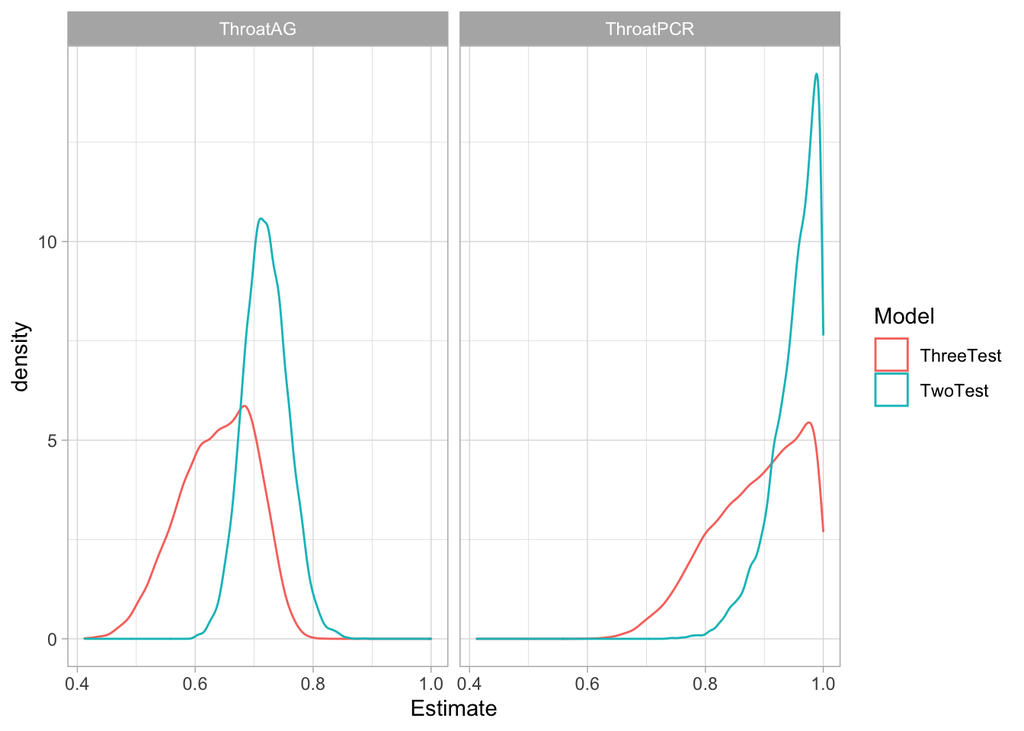

```r
test2 <- combine.mcmc(results_2t, vars="se", return.samples = 10000)
test3 <- combine.mcmc(results_3t, vars="se[2:3]", return.samples = 10000)

bind_rows(
  tibble(Model = "TwoTest", ThroatAG = test2[,1], ThroatPCR = test2[,2]),
  tibble(Model = "ThreeTest", ThroatAG = test3[,1], ThroatPCR = test3[,2])
) %>%
  pivot_longer(c(ThroatAG, ThroatPCR), names_to = "Test", values_to = "Estimate") %>%
  ggplot() +
  aes(x = Estimate, col = Model) +
  geom_density() +
  facet_wrap( ~ Test)
```

However, they do look more similar to the probabilities of detection conditional on shedding:

```r
antigen_detection
## [1] 0.75
pcr_detection
## [1] 0.999
```

Have a think about why this might be the case. We will spend a lot of time discussing this topic tomorrow!

## Optional exercise A

Re-fit a model to this data using all three possible covse and covsp parameters between all 3 tests

What do you notice about the results?

### Solution A

You can either manually change all 3 covse/covsp from before, or regenerate the model using the covariance=TRUE option:

```r
template_huiwalter(covid_data %>% select(Population, NoseAG, ThroatAG, ThroatPCR), outfile='covidmodel_allcov.txt', covariance=TRUE)
results_allcov <- run.jags('covidmodel_allcov.txt')
```

```r
results_allcov
##
## JAGS model summary statistics from 20000 samples (chains = 2; adapt+burnin = 5000):
##
##              Lower95       Median    Upper95         Mean         SD
## se[1]        0.50757      0.60513    0.70399      0.60531   0.050386
## se[2]        0.43948      0.60808    0.76472      0.60638   0.088334
## se[3]        0.71747      0.88268    0.99979      0.87245    0.08408
## sp[1]        0.94396      0.94879    0.95378      0.94888  0.0025463
## sp[2]        0.94442      0.94822    0.95225      0.94824  0.0020231
## sp[3]        0.98744      0.98998    0.99244      0.98999   0.001275
## prev[1]    0.0046611     0.007301   0.010813    0.0074707  0.0016269
## prev[2]     0.039127     0.047994   0.061164     0.049026  0.0059961
## covse12    -0.015084     0.016533   0.045938     0.015937   0.015964
## corse12      -0.1289     0.084098    0.24815     0.075675    0.09744
## covsp12  -0.00067244 -0.000086619 0.00050238 -0.000086222 0.00029739
## corsp12     -0.22063    -0.032424   0.016906    -0.061447   0.078087
## covse13    -0.037593   -0.0055042   0.025573   -0.0060422   0.016071
## corse13     -0.99998     -0.15547    0.52308     -0.18378    0.41125
## covsp13 -0.000095692   0.00050469  0.0010622   0.00049697 0.00029558
## corsp13    -0.031732     0.053029    0.14037     0.039071   0.094083
## covse23   -0.0042523     0.049091   0.096317     0.046964   0.030331
## corse23    -0.029579       0.6814    0.99998      0.60348    0.34395
## covsp23  -0.00034469   0.00023566 0.00075905    0.0002306 0.00028623
## corsp23     -0.54367     0.024807     0.1052    -0.045662    0.19563
##
##                 Mode       MCerr MC%ofSD SSeff    AC.10   psrf
## se[1]        0.60037   0.0016286     3.2   957  0.37992 1.0026
## se[2]        0.61266   0.0070521       8   157  0.77906 1.0012
## se[3]         0.9011   0.0064525     7.7   170  0.83158 1.0015
## sp[1]        0.94861  0.00012824       5   394  0.45561      1
## sp[2]        0.94833 0.000063577     3.1  1013  0.21132 1.0002
## sp[3]        0.98994 0.000028902     2.3  1946   0.1745      1
## prev[1]    0.0070744 0.000073481     4.5   490  0.34634 1.0002
## prev[2]     0.046493  0.00041044     6.8   213  0.70168 1.0015
## covse12     0.018386  0.00047623       3  1124  0.30829 1.0013
## corse12     0.089849   0.0029226       3  1112  0.30395 1.0014
## covsp12 -0.000091489  5.2002e-06     1.7  3270 0.064398 1.0008
## corsp12   -0.0013687   0.0012956     1.7  3632 0.046137 1.0005
## covse13   -0.0047536  0.00054671     3.4   864  0.42797 1.0008
## corse13     -0.08745    0.011471     2.8  1285  0.24301 1.0001
## covsp13   0.00052327  5.1278e-06     1.7  3323 0.043924 1.0001
## corsp13     0.053448   0.0013586     1.4  4796 0.019353 1.0057
## covse23      0.06289   0.0023805     7.8   162  0.83854 1.0018
## corse23       0.8048    0.016301     4.7   445  0.34518 1.0022
## covsp23   0.00024643  4.8658e-06     1.7  3460 0.050185      1
## corsp23     0.025683   0.0030325     1.6  4162 0.037497      1
##
## Total time taken: 1.9 seconds
```

The effective sample size is much lower, because the model is less identifiable. But otherwise the model does a reasonable job of estimating the parameters due to the large sample size, albeit with wider 95% CI then with only covariance between throat swab tests included This might not be the case with a smaller sample size!

## Summary

- Including multiple tests is technically easy
  - But philosophically more difficult!!!
- Complexity of adding correlation terms increases non-linearly with more tests
  - Probably best to stick to correlations with biological justification?
- Adding/removing test results may change the posterior for
  - Other test Se / Sp
  - Prevalence